# GAM model building

RMSE Error: * Validation error slightly better actually and concurvity between mean income and poverty metric didn’t change much, but maybe wait and see to remove alprazolam?

Try: sub 6 - but take out mean house inc - strong relationship with pop struggling and x,y:

```r
full_model_sub9 <- gam(
    death_count_next_year ~ s(x,y) + s(year, k=3) + s(tot_pop) + s(pop_struggling_prop) + town_status + s(opioid_rate_avg) + s(alprazolam_per_65_and_over) + s(lorazepam_per_65_and_over),
    data = train_set, method = "REML", family = nb(), select = TRUE
    )
summary(full_model_sub9)
```

```
##
## Family: Negative Binomial(5.23)
## Link function: log
##
## Formula:
## death_count_next_year ~ s(x, y) + s(year, k = 3) + s(tot_pop) +
##     s(pop_struggling_prop) + town_status + s(opioid_rate_avg) +
##     s(alprazolam_per_65_and_over) + s(lorazepam_per_65_and_over)
##
## Parametric coefficients:
##                      Estimate Std. Error z value Pr(>|z|)
## (Intercept)           0.65460    0.04575  14.307  < 2e-16 ***
## town_statusshrunk     0.41769    0.18338   2.278  0.02274 *
## town_statusuncertain  0.46607    0.15990   2.915  0.00356 **
## ---
## Signif. codes:  0 '***' 0.001 '**' 0.01 '*' 0.05 '.' 0.1 ' ' 1
##
## Approximate significance of smooth terms:
##                                   edf Ref.df  Chi.sq  p-value
## s(x,y)                        11.7666     29  81.254  < 2e-16 ***
## s(year)                        0.9763      2  38.766 2.53e-10 ***
## s(tot_pop)                     7.5804      9 467.895  < 2e-16 ***
## s(pop_struggling_prop)         3.4626      9 116.843  < 2e-16 ***
## s(opioid_rate_avg)             4.1689      9  25.244 8.87e-06 ***
## s(alprazolam_per_65_and_over)  2.0241      9   7.477  0.00808 **
## s(lorazepam_per_65_and_over)   6.5434      9  27.813 2.45e-05 ***
## ---
## Signif. codes:  0 '***' 0.001 '**' 0.01 '*' 0.05 '.' 0.1 ' ' 1
##
## R-sq.(adj) =  0.944   Deviance explained = 84.7%
## -REML = 1545.7  Scale est. = 1         n = 768
```

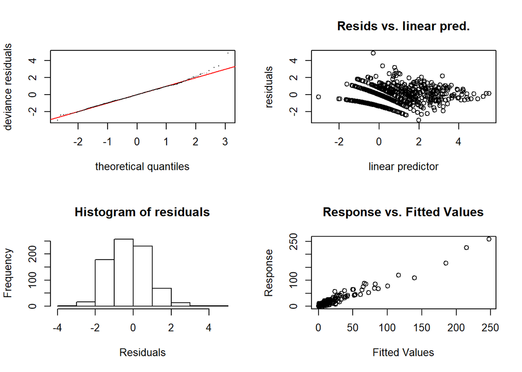

```
##
## Method: REML   Optimizer: outer newton
## full convergence after 10 iterations.
## Gradient range [-0.0005189308,0.0002355942]
## (score 1545.68 & scale 1).
## eigenvalue range [-2.865926e-05,41.21041].
## Model rank =  79 / 79
##
## Basis dimension (k) checking results. Low p-value (k-index<1) may
## indicate that k is too low, especially if edf is close to k'.
##
##                                   k'    edf k-index p-value
## s(x,y)                        29.000 11.767    0.74  <2e-16 ***
## s(year)                        2.000  0.976    0.94   0.395
## s(tot_pop)                     9.000  7.580    0.80  <2e-16 ***
## s(pop_struggling_prop)         9.000  3.463    0.75  <2e-16 ***
## s(opioid_rate_avg)             9.000  4.169    0.95   0.490
## s(alprazolam_per_65_and_over)  9.000  2.024    0.87   0.005 **
## s(lorazepam_per_65_and_over)   9.000  6.543    0.98   0.755
## ---
## Signif. codes:  0 '***' 0.001 '**' 0.01 '*' 0.05 '.' 0.1 ' ' 1
```

```r
gam.check(full_model_sub9)
```

```r
concurvity(full_model_sub9)
```

```
##               para    s(x,y)    s(year) s(tot_pop) s(pop_struggling_prop)
## worst    0.4848953 0.8340929 0.06316256  0.7404139              0.6871433
## observed 0.4848953 0.5106514 0.06091686  0.7285895              0.6749553
## estimate 0.4848953 0.3051489 0.05782023  0.2313305              0.5658921
##          s(opioid_rate_avg) s(alprazolam_per_65_and_over)
## worst             0.3984308                     0.8069839
## observed          0.3161000                     0.7375379
## estimate          0.1936939                     0.5611765
##          s(lorazepam_per_65_and_over)
## worst                       0.8097794
## observed                    0.4392259
## estimate                    0.5782348
```

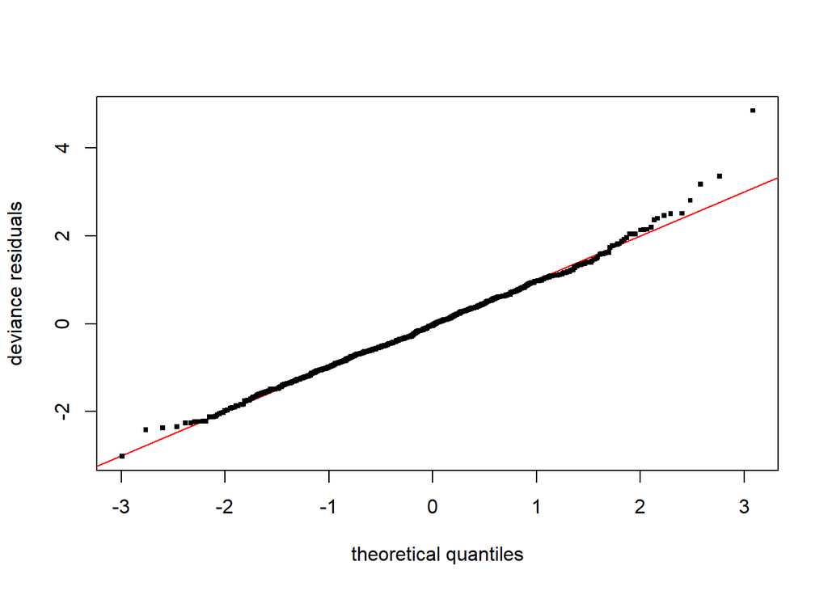

```r
qq.gam(full_model_sub9, cex = 4)
```

```r
# error on training
rmse(full_model_sub9, train_set)
```

```
## [1] 4.278446
```

```r
# error on validation
rmse(full_model_sub9, valid_set)
```

```
## [1] 8.756944
```

```r
rmse(full_model_sub6, valid_set)
```

```
## [1] 7.939338
```

Notes:

GAM Summary: * n/A

GAM check: * ignore

Concurvity: * all features now have worst-case concurvity estimates below the desired threshold of 0.84

RMSE Error: * Error on validation is higher with this iteration than the previous one (sub6)

Try taking out poverty metric from model sub 6 instead? Will the validation error be lower with version sub 9 or sub 10?

```r
full_model_sub10 <- gam(
    death_count_next_year ~ s(x,y) + s(year, k=3) + s(tot_pop) + s(mean_house_inc) + town_status + s(opioid_rate_avg) + s(alprazolam_per_65_and_over) + s(lorazepam_per_65_and_over),
    data = train_set, method = "REML", family = nb(), select = TRUE
    )
summary(full_model_sub10)
```

```
##
## Family: Negative Binomial(4.617)
## Link function: log
##
## Formula:
## death_count_next_year ~ s(x, y) + s(year, k = 3) + s(tot_pop) +
##     s(mean_house_inc) + town_status + s(opioid_rate_avg) + s(alprazolam_per_65_and_over) +
##     s(lorazepam_per_65_and_over)
##
## Parametric coefficients:
##                      Estimate Std. Error z value Pr(>|z|)
## (Intercept)           0.65370    0.04607  14.189  < 2e-16 ***
## town_statusshrunk     0.38443    0.17758   2.165  0.03040 *
## town_statusuncertain  0.47557    0.15807   3.009  0.00262 **
## ---
## Signif. codes:  0 '***' 0.001 '**' 0.01 '*' 0.05 '.' 0.1 ' ' 1
##
## Approximate significance of smooth terms:
##                                  edf Ref.df  Chi.sq  p-value
## s(x,y)                        9.8793     29  93.080  < 2e-16 ***
## s(year)                       0.9746      2  37.518 4.86e-10 ***
## s(tot_pop)                    7.1695      9 601.761  < 2e-16 ***
## s(mean_house_inc)             4.1570      9 147.449  < 2e-16 ***
## s(opioid_rate_avg)            4.2807      9  30.601 5.78e-07 ***
## s(alprazolam_per_65_and_over) 1.5695      9   3.804  0.04583 *
## s(lorazepam_per_65_and_over)  1.7804      9   8.189  0.00185 **
## ---
## Signif. codes:  0 '***' 0.001 '**' 0.01 '*' 0.05 '.' 0.1 ' ' 1
##
## R-sq.(adj) =  0.942   Deviance explained =   84%
## -REML = 1535.4  Scale est. = 1         n = 768
```

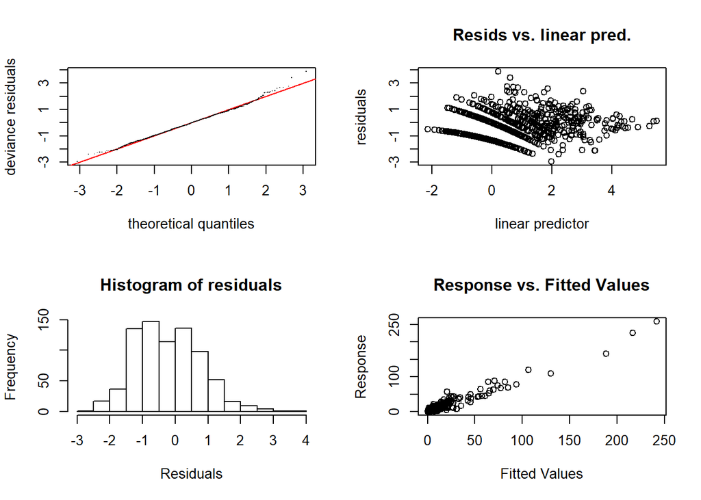

```
##
## Method: REML   Optimizer: outer newton
## full convergence after 17 iterations.
## Gradient range [-0.0003083863,5.612812e-05]
## (score 1535.355 & scale 1).
## Hessian positive definite, eigenvalue range [6.153069e-05,49.57112].
## Model rank =  79 / 79
##
## Basis dimension (k) checking results. Low p-value (k-index<1) may
## indicate that k is too low, especially if edf is close to k'.
##
##                                   k'    edf k-index p-value
## s(x,y)                        29.000  9.879    0.73  <2e-16 ***
## s(year)                        2.000  0.975    0.99    0.84
## s(tot_pop)                     9.000  7.170    0.82  <2e-16 ***
## s(mean_house_inc)              9.000  4.157    0.76  <2e-16 ***
## s(opioid_rate_avg)             9.000  4.281    0.96    0.56
## s(alprazolam_per_65_and_over)  9.000  1.570    0.87    0.01 **
## s(lorazepam_per_65_and_over)   9.000  1.780    0.93    0.30
## ---
## Signif. codes:  0 '***' 0.001 '**' 0.01 '*' 0.05 '.' 0.1 ' ' 1
```

```r
gam.check(full_model_sub10)
```

```r
concurvity(full_model_sub10)
```

```
##               para    s(x,y)    s(year) s(tot_pop) s(mean_house_inc)
## worst    0.4709746 0.8208753 0.06288540  0.7301518         0.7021433
## observed 0.4709746 0.5167042 0.06065369  0.7070382         0.6766099
## estimate 0.4709746 0.2886102 0.05757363  0.1975877         0.5014525
##          s(opioid_rate_avg) s(alprazolam_per_65_and_over)
## worst             0.3879040                     0.8135127
## observed          0.3344230                     0.7013431
## estimate          0.1914694                     0.5545192
##          s(lorazepam_per_65_and_over)
## worst                       0.8139729
## observed                    0.7723336
## estimate                    0.5752115
```

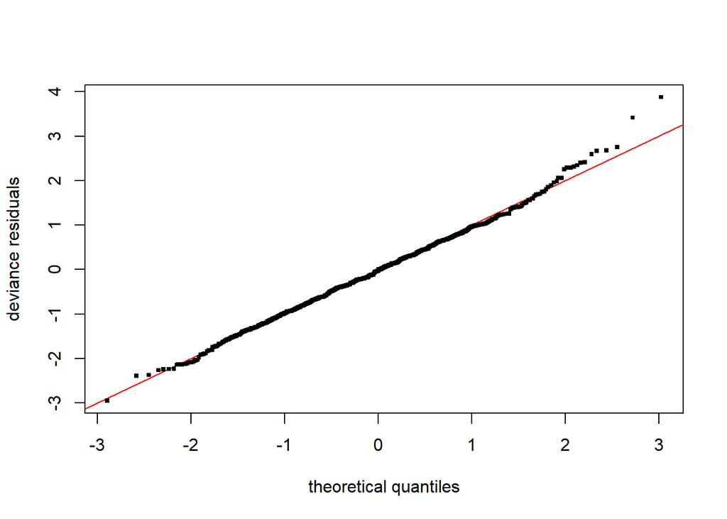

```r
qq.gam(full_model_sub10, cex = 4)
```

```r
# error on training
rmse(full_model_sub10, train_set)
```

```
## [1] 4.405427
```

```r
# error on validation
rmse(full_model_sub10, valid_set)
```

```
## [1] 7.708673
```

```r
rmse(full_model_sub6, valid_set)
```

```
## [1] 7.939338
```

Notes:

GAM Summary: * N/A

GAM check: * ignore

Concurvity: * all concurvity metrics below desired threshold of 0.84 with this version also

RMSE Error: * Validation error actually went down between previous iteration (sub6) and this one, much better than when the mean income was removed (sub9)

Last check - does removing the town shrunk/grown feature change things?

```r
full_model_sub10_alt <- gam(
    death_count_next_year ~ s(x,y) + s(year, k=3) + s(tot_pop) + s(mean_house_inc) + s(opioid_rate_avg) + s(alprazolam_per_65_and_over) + s(lorazepam_per_65_and_over),
    data = train_set, method = "REML", family = nb(), select = TRUE
    )
summary(full_model_sub10_alt)
```

```
##
## Family: Negative Binomial(4.432)
## Link function: log
##
## Formula:
## death_count_next_year ~ s(x, y) + s(year, k = 3) + s(tot_pop) +
##     s(mean_house_inc) + s(opioid_rate_avg) + s(alprazolam_per_65_and_over) +
##     s(lorazepam_per_65_and_over)
##
## Parametric coefficients:
##             Estimate Std. Error z value Pr(>|z|)
## (Intercept)  0.73684    0.03688   19.98   <2e-16 ***
## ---
## Signif. codes:  0 '***' 0.001 '**' 0.01 '*' 0.05 '.' 0.1 ' ' 1
##
## Approximate significance of smooth terms:
##                                  edf Ref.df  Chi.sq  p-value
## s(x,y)                        9.9835     29  85.545  < 2e-16 ***
## s(year)                       0.9741      2  36.871 6.77e-10 ***
## s(tot_pop)                    6.9430      9 595.228  < 2e-16 ***
## s(mean_house_inc)             4.0315      9 147.155  < 2e-16 ***
## s(opioid_rate_avg)            4.1993      9  31.121 3.82e-07 ***
## s(alprazolam_per_65_and_over) 1.5370      9   3.483  0.05643 .
## s(lorazepam_per_65_and_over)  1.7068      9   8.306  0.00139 **
## ---
## Signif. codes:  0 '***' 0.001 '**' 0.01 '*' 0.05 '.' 0.1 ' ' 1
##
## R-sq.(adj) =  0.941   Deviance explained = 83.6%
## -REML = 1538.4  Scale est. = 1         n = 768
```

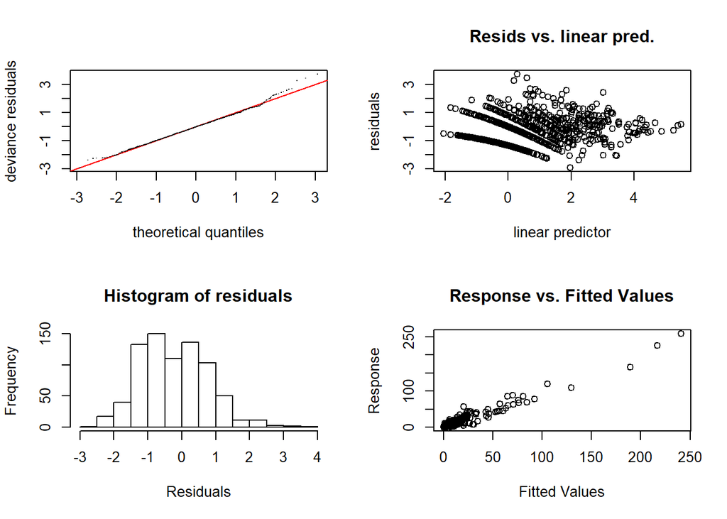

```
##
## Method: REML   Optimizer: outer newton
## full convergence after 17 iterations.
## Gradient range [-0.0001471584,2.653199e-05]
## (score 1538.442 & scale 1).
## Hessian positive definite, eigenvalue range [4.329068e-06,51.14901].
## Model rank =  77 / 77
##
## Basis dimension (k) checking results. Low p-value (k-index<1) may
## indicate that k is too low, especially if edf is close to k'.
##
##                                   k'    edf k-index p-value
## s(x,y)                        29.000  9.984    0.72  <2e-16 ***
## s(year)                        2.000  0.974    0.99   0.900
## s(tot_pop)                     9.000  6.943    0.82  <2e-16 ***
## s(mean_house_inc)              9.000  4.032    0.75  <2e-16 ***
## s(opioid_rate_avg)             9.000  4.199    0.95   0.425
## s(alprazolam_per_65_and_over)  9.000  1.537    0.87   0.005 **
## s(lorazepam_per_65_and_over)   9.000  1.707    0.92   0.230
## ---
## Signif. codes:  0 '***' 0.001 '**' 0.01 '*' 0.05 '.' 0.1 ' ' 1
```

```r
gam.check(full_model_sub10_alt)
```

```r
concurvity(full_model_sub10_alt)
```

```
##                  para    s(x,y)    s(year) s(tot_pop) s(mean_house_inc)
## worst    8.280808e-21 0.7716757 0.06259101  0.7221676         0.6984590
## observed 8.280808e-21 0.3748237 0.06041858  0.6993512         0.6748745
## estimate 8.280808e-21 0.2525630 0.05734661  0.1969129         0.5002765
##          s(opioid_rate_avg) s(alprazolam_per_65_and_over)
## worst             0.3812741                     0.8134794
## observed          0.3252685                     0.6889116
## estimate          0.1865405                     0.5544226
##          s(lorazepam_per_65_and_over)
## worst                       0.8137866
## observed                    0.7665397
## estimate                    0.5718693
```

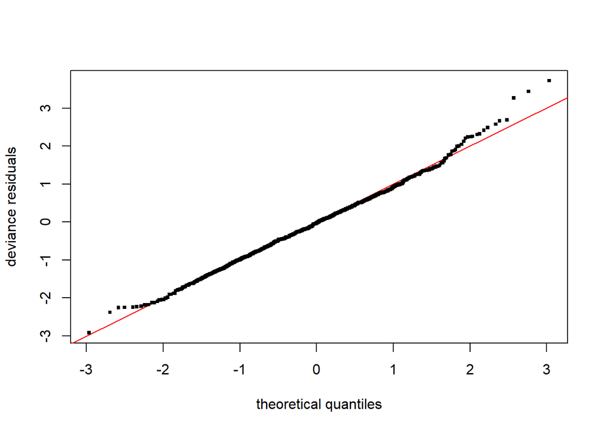

```r
qq.gam(full_model_sub10_alt, cex = 4)
```

```r
# error on training
rmse(full_model_sub10_alt, train_set)
```

```
## [1] 4.426153
```

```r
# error on validation
rmse(full_model_sub10, valid_set)
```

```
## [1] 7.708673
```

```r
rmse(full_model_sub10_alt, valid_set)
```

```
## [1] 7.707861
```

A: no

- Features tentatively finalized

Try raising k again (because of gam check results), but on mod 10 - does it make a differnce? Improve fit?

```r
full_model_sub11 <- gam(
    death_count_next_year ~ s(x,y, k = 45) + s(year, k=3) + s(tot_pop, k = 15) + s(mean_house_inc, k = 15) + town_status + s(opioid_rate_avg) + s(alprazolam_per_65_and_over, k = 15) + s(lorazepam_per_65_and_over),
    data = train_set, method = "REML", family = nb(), select = TRUE
    )
summary(full_model_sub11)
```

```
##
## Family: Negative Binomial(4.818)
## Link function: log
##
## Formula:
## death_count_next_year ~ s(x, y, k = 45) + s(year, k = 3) + s(tot_pop,
##     k = 15) + s(mean_house_inc, k = 15) + town_status + s(opioid_rate_avg) +
##     s(alprazolam_per_65_and_over, k = 15) + s(lorazepam_per_65_and_over)
##
## Parametric coefficients:
##                      Estimate Std. Error z value Pr(>|z|)
## (Intercept)           0.64521    0.04688  13.763  < 2e-16 ***
## town_statusshrunk     0.39286    0.18553   2.118  0.03421 *
## town_statusuncertain  0.49958    0.16221   3.080  0.00207 **
## ---
## Signif. codes:  0 '***' 0.001 '**' 0.01 '*' 0.05 '.' 0.1 ' ' 1
##
## Approximate significance of smooth terms:
##                                   edf Ref.df  Chi.sq  p-value
## s(x,y)                        13.4575     44 102.663  < 2e-16 ***
## s(year)                        0.9747      2  37.624 4.59e-10 ***
## s(tot_pop)                     8.3345     14 580.342  < 2e-16 ***
## s(mean_house_inc)              4.3565     14 144.238  < 2e-16 ***
## s(opioid_rate_avg)             4.2379      9  29.423 9.54e-07 ***
## s(alprazolam_per_65_and_over)  1.4545     14   3.306  0.05415 .
## s(lorazepam_per_65_and_over)   1.8675      9   8.634  0.00133 **
## ---
## Signif. codes:  0 '***' 0.001 '**' 0.01 '*' 0.05 '.' 0.1 ' ' 1
##
## R-sq.(adj) =  0.942   Deviance explained = 84.5%
## -REML = 1534.1  Scale est. = 1         n = 768
```

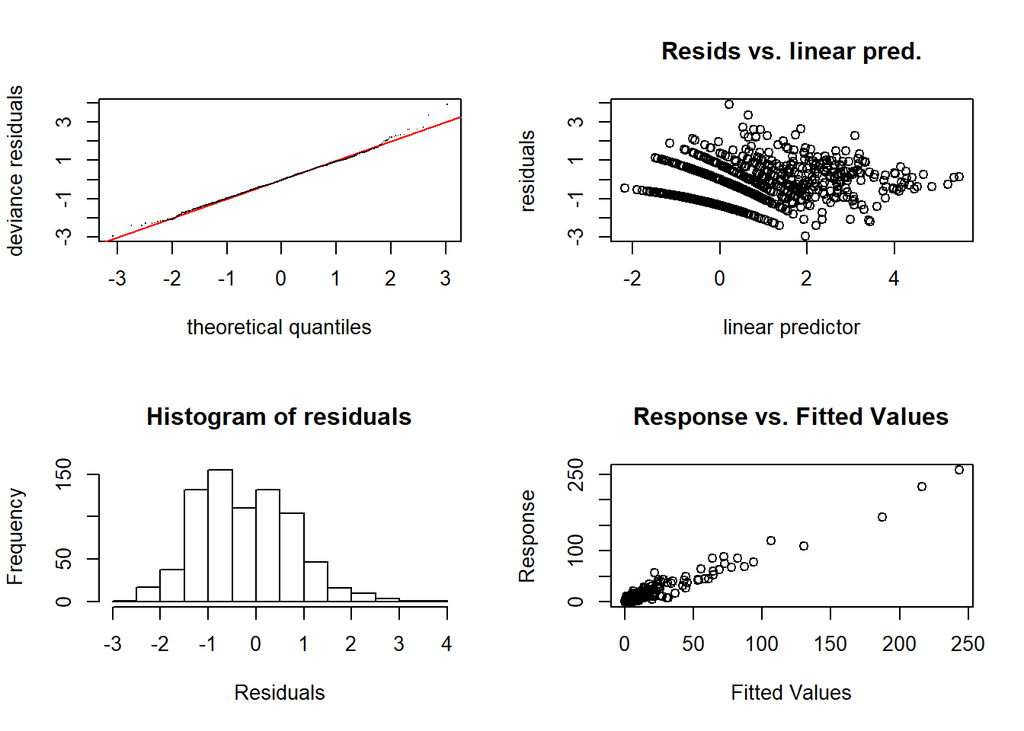

```
##
## Method: REML   Optimizer: outer newton
## full convergence after 14 iterations.
## Gradient range [-0.000830218,0.000103467]
## (score 1534.143 & scale 1).
## Hessian positive definite, eigenvalue range [6.561069e-05,46.98544].
## Model rank =  109 / 109
##
## Basis dimension (k) checking results. Low p-value (k-index<1) may
## indicate that k is too low, especially if edf is close to k'.
##
##                                   k'    edf k-index p-value
## s(x,y)                        44.000 13.457    0.75  <2e-16 ***
## s(year)                        2.000  0.975    0.99   0.930
## s(tot_pop)                    14.000  8.335    0.83  <2e-16 ***
## s(mean_house_inc)             14.000  4.357    0.77  <2e-16 ***
## s(opioid_rate_avg)             9.000  4.238    0.96   0.680
## s(alprazolam_per_65_and_over) 14.000  1.454    0.87   0.015 *
## s(lorazepam_per_65_and_over)   9.000  1.867    0.93   0.280
## ---
## Signif. codes:  0 '***' 0.001 '**' 0.01 '*' 0.05 '.' 0.1 ' ' 1
```

```r
gam.check(full_model_sub11)
```

```r
concurvity(full_model_sub11)
```

```
##               para    s(x,y)    s(year) s(tot_pop) s(mean_house_inc)
## worst    0.5211576 0.8623791 0.08156321  0.7986198         0.7502896
## observed 0.5211576 0.5622594 0.08053803  0.7420858         0.7216521
## estimate 0.5211576 0.3510123 0.07657780  0.2368930         0.5494401
##          s(opioid_rate_avg) s(alprazolam_per_65_and_over)
## worst             0.4461322                     0.8430972
## observed          0.3814894                     0.7641974
## estimate          0.2315566                     0.5892124
##          s(lorazepam_per_65_and_over)
## worst                       0.8464195
## observed                    0.8090500
## estimate                    0.6520093
```

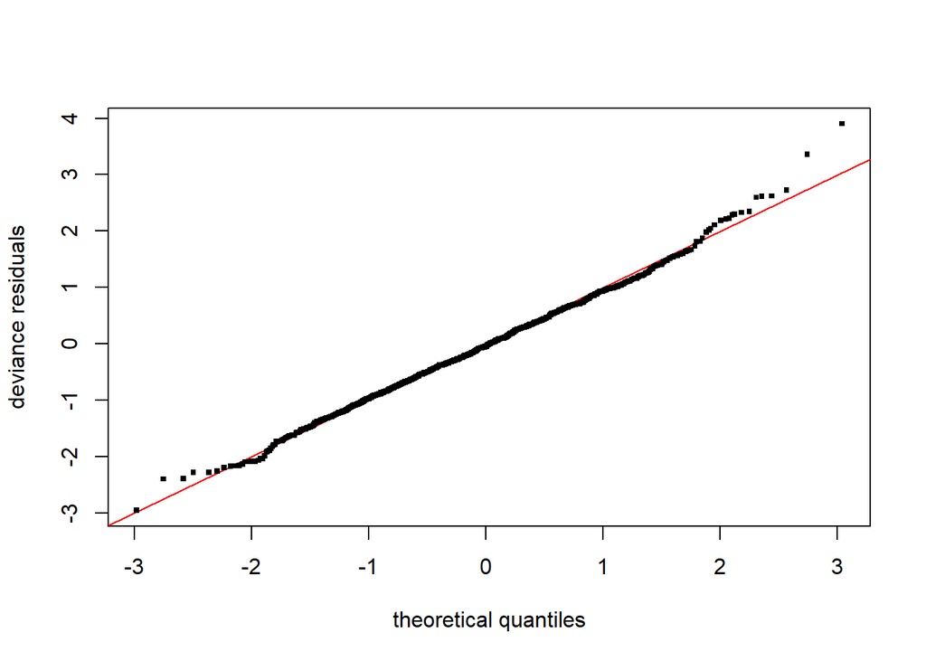

```r
qq.gam(full_model_sub11, cex = 4)
```

```r
# error on training
rmse(full_model_sub11, train_set)
```

```
## [1] 4.363249
```

```r
# error on validation
rmse(full_model_sub11, valid_set)
```

```
## [1] 7.708276
```

```r
rmse(full_model_sub10, valid_set)
```

```
## [1] 7.708673
```

Notes:

GAM check: * Increasing k doesn’t seem to have done much - all features that had a p < 0.05 also have a p < 0.05 in this version. Is it worth it to raise k?

Concurvity: * Worst-case concurvity estimates for `alprazolam_per_65_and_over` and `lorazepam_per_65_and_over` are now at/above desired threshold of 0.84.

- Not worth it - likely increasing overfitting here with little to no benefit

Try rolling back k for x,y and mean house inc?

```r
full_model_sub12 <- gam(
    death_count_next_year ~ s(x,y) + s(year, k=3) + s(tot_pop, k = 15) + s(mean_house_inc) + town_status + s(opioid_rate_avg) + s(alprazolam_per_65_and_over, k = 15) + s(lorazepam_per_65_and_over),
    data = train_set, method = "REML", family = nb(), select = TRUE
    )
summary(full_model_sub12)
```

```
##
## Family: Negative Binomial(4.69)
## Link function: log
##
## Formula:
## death_count_next_year ~ s(x, y) + s(year, k = 3) + s(tot_pop,
##     k = 15) + s(mean_house_inc) + town_status + s(opioid_rate_avg) +
##     s(alprazolam_per_65_and_over, k = 15) + s(lorazepam_per_65_and_over)
##
## Parametric coefficients:
##                      Estimate Std. Error z value Pr(>|z|)
## (Intercept)           0.64999    0.04617  14.079   <2e-16 ***
## town_statusshrunk     0.38478    0.17747   2.168   0.0301 *
## town_statusuncertain  0.48138    0.15788   3.049   0.0023 **
## ---
## Signif. codes:  0 '***' 0.001 '**' 0.01 '*' 0.05 '.' 0.1 ' ' 1
##
## Approximate significance of smooth terms:
##                                  edf Ref.df  Chi.sq  p-value
## s(x,y)                        9.8061     29  91.935  < 2e-16 ***
## s(year)                       0.9746      2  37.609 4.65e-10 ***
## s(tot_pop)                    8.4536     14 609.662  < 2e-16 ***
## s(mean_house_inc)             4.1247      9 147.820  < 2e-16 ***
## s(opioid_rate_avg)            4.2794      9  30.337 6.64e-07 ***
## s(alprazolam_per_65_and_over) 1.5176     14   3.497  0.05377 .
## s(lorazepam_per_65_and_over)  1.8040      9   8.550  0.00142 **
## ---
## Signif. codes:  0 '***' 0.001 '**' 0.01 '*' 0.05 '.' 0.1 ' ' 1
##
## R-sq.(adj) =  0.942   Deviance explained = 84.1%
## -REML = 1534.9  Scale est. = 1         n = 768
```

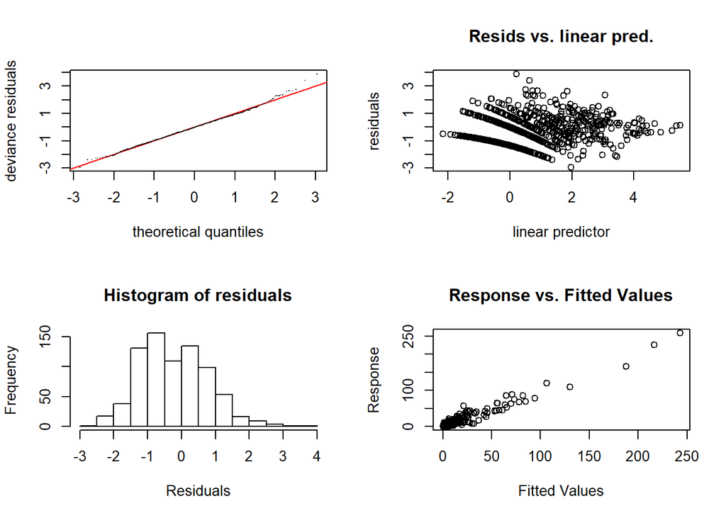

```
##
## Method: REML   Optimizer: outer newton
## full convergence after 12 iterations.
## Gradient range [-0.0001036887,0.0001465569]
## (score 1534.939 & scale 1).
## Hessian positive definite, eigenvalue range [3.764413e-06,48.39444].
## Model rank =  89 / 89
##
## Basis dimension (k) checking results. Low p-value (k-index<1) may
## indicate that k is too low, especially if edf is close to k'.
##
##                                   k'    edf k-index p-value
## s(x,y)                        29.000  9.806    0.74  <2e-16 ***
## s(year)                        2.000  0.975    0.99    0.90
## s(tot_pop)                    14.000  8.454    0.83  <2e-16 ***
## s(mean_house_inc)              9.000  4.125    0.76  <2e-16 ***
## s(opioid_rate_avg)             9.000  4.279    0.96    0.60
## s(alprazolam_per_65_and_over) 14.000  1.518    0.87    0.01 **
## s(lorazepam_per_65_and_over)   9.000  1.804    0.93    0.26
## ---
## Signif. codes:  0 '***' 0.001 '**' 0.01 '*' 0.05 '.' 0.1 ' ' 1
```

```r
gam.check(full_model_sub12)
```

```r
concurvity(full_model_sub12)
```

```
##              para    s(x,y)    s(year) s(tot_pop) s(mean_house_inc)
## worst    0.483887 0.8437466 0.07731671  0.7567530         0.7162737
## observed 0.483887 0.5546737 0.07652393  0.7129065         0.6857582
## estimate 0.483887 0.3208393 0.07265166  0.2003763         0.5158464
##          s(opioid_rate_avg) s(alprazolam_per_65_and_over)
## worst             0.3997137                     0.8224550
## observed          0.3445021                     0.7174671
## estimate          0.2027966                     0.5585318
##          s(lorazepam_per_65_and_over)
## worst                       0.8219495
## observed                    0.7818491
## estimate                    0.5973384
```

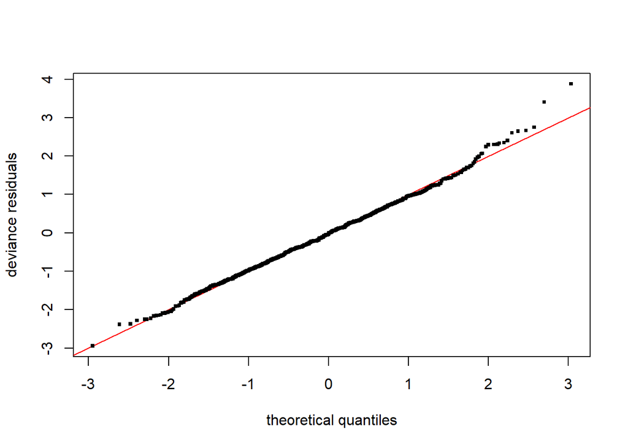

```r
qq.gam(full_model_sub12, cex = 4)
```

```r
# error on training
rmse(full_model_sub12, train_set)
```

```
## [1] 4.37465
```

```r
rmse(full_model_sub10, train_set)
```

```
## [1] 4.405427
```

```r
# error on validation
rmse(full_model_sub12, valid_set)
```

```
## [1] 7.680931
```

```r
rmse(full_model_sub11, valid_set)
```

```
## [1] 7.708276
```

```r
rmse(full_model_sub10, valid_set)
```

```
## [1] 7.708673
```

Notes:

- Again, error doesn’t change much and there doesn’t seem to be a benefit to making the model more flexible by increasing k

```r
full_model_sub13 <- gam(
    death_count_next_year ~ s(x,y) + s(year, k=3) + s(tot_pop) + s(mean_house_inc) + town_status + s(opioid_rate_avg) + s(alprazolam_per_65_and_over, k = 18) + s(lorazepam_per_65_and_over),
    data = train_set, method = "REML", family = nb(), select = TRUE
    )
summary(full_model_sub13)
```

```
##
## Family: Negative Binomial(4.616)
## Link function: log
##
## Formula:
## death_count_next_year ~ s(x, y) + s(year, k = 3) + s(tot_pop) +
##     s(mean_house_inc) + town_status + s(opioid_rate_avg) + s(alprazolam_per_65_and_over,
##     k = 18) + s(lorazepam_per_65_and_over)
##
## Parametric coefficients:
##                      Estimate Std. Error z value Pr(>|z|)
## (Intercept)           0.65369    0.04607  14.188  < 2e-16 ***
## town_statusshrunk     0.38448    0.17761   2.165  0.03040 *
## town_statusuncertain  0.47564    0.15808   3.009  0.00262 **
## ---
## Signif. codes:  0 '***' 0.001 '**' 0.01 '*' 0.05 '.' 0.1 ' ' 1
##
## Approximate significance of smooth terms:
##                                  edf Ref.df  Chi.sq  p-value
## s(x,y)                        9.8846     29  93.130  < 2e-16 ***
## s(year)                       0.9744      2  37.516 4.86e-10 ***
## s(tot_pop)                    7.1698      9 601.598  < 2e-16 ***
## s(mean_house_inc)             4.1577      9 147.450  < 2e-16 ***
## s(opioid_rate_avg)            4.2810      9  30.609 5.75e-07 ***
## s(alprazolam_per_65_and_over) 1.5731     17   3.780  0.04683 *
## s(lorazepam_per_65_and_over)  1.7818      9   8.191  0.00186 **
## ---
## Signif. codes:  0 '***' 0.001 '**' 0.01 '*' 0.05 '.' 0.1 ' ' 1
##
## R-sq.(adj) =  0.942   Deviance explained =   84%
## -REML = 1535.4  Scale est. = 1         n = 768
```

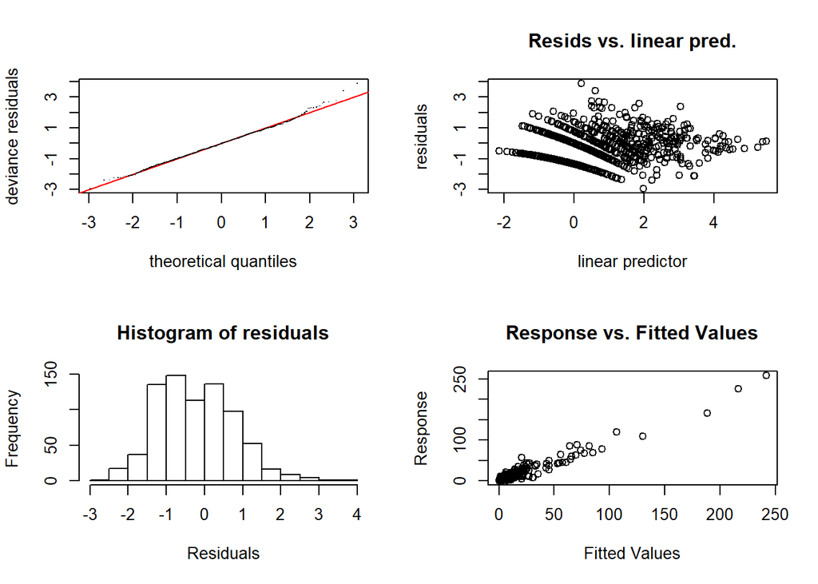

```
##
## Method: REML   Optimizer: outer newton
## full convergence after 18 iterations.
## Gradient range [-3.632402e-05,2.314691e-05]
## (score 1535.368 & scale 1).
## Hessian positive definite, eigenvalue range [1.963427e-05,49.57163].
## Model rank =  87 / 87
##
## Basis dimension (k) checking results. Low p-value (k-index<1) may
## indicate that k is too low, especially if edf is close to k'.
##
##                                   k'    edf k-index p-value
## s(x,y)                        29.000  9.885    0.73  <2e-16 ***
## s(year)                        2.000  0.974    0.99    0.88
## s(tot_pop)                     9.000  7.170    0.82  <2e-16 ***
## s(mean_house_inc)              9.000  4.158    0.76  <2e-16 ***
## s(opioid_rate_avg)             9.000  4.281    0.96    0.60
## s(alprazolam_per_65_and_over) 17.000  1.573    0.87    0.01 **
## s(lorazepam_per_65_and_over)   9.000  1.782    0.93    0.25
## ---
## Signif. codes:  0 '***' 0.001 '**' 0.01 '*' 0.05 '.' 0.1 ' ' 1
```

```r
gam.check(full_model_sub13)
```

```r
concurvity(full_model_sub13)
```

```
##              para    s(x,y)    s(year) s(tot_pop) s(mean_house_inc)
## worst    0.476432 0.8234735 0.07654480  0.7353482         0.7076583
## observed 0.476432 0.5267941 0.07597409  0.7130938         0.6815434
## estimate 0.476432 0.2981608 0.07244195  0.2095203         0.5056089
##          s(opioid_rate_avg) s(alprazolam_per_65_and_over)
## worst             0.4040073                     0.8205088
## observed          0.3452225                     0.7023691
## estimate          0.2021673                     0.5390463
##          s(lorazepam_per_65_and_over)
## worst                       0.8207451
## observed                    0.7786235
## estimate                    0.6053264
```

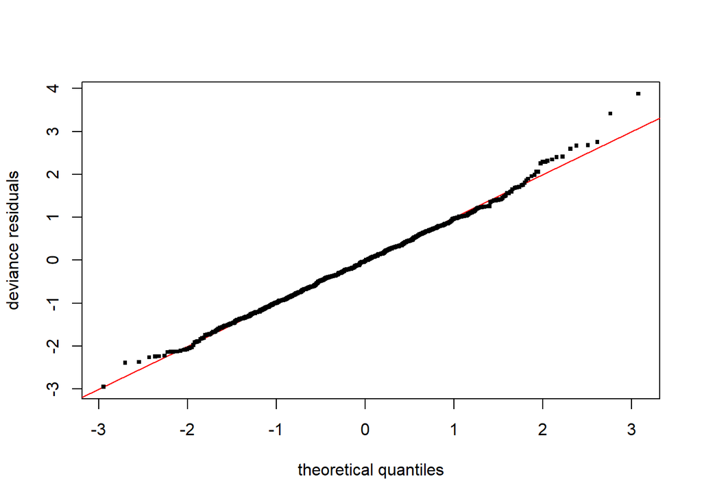

```r
qq.gam(full_model_sub13, cex = 4)
```

```r
# error on training
rmse(full_model_sub13, train_set)
```

```
## [1] 4.404802
```

```r
rmse(full_model_sub10, train_set)
```

```
## [1] 4.405427
```

```r
# error on validation
rmse(full_model_sub13, valid_set)
```

```
## [1] 7.706749
```

```r
rmse(full_model_sub12, valid_set)
```

```
## [1] 7.680931
```

```r
rmse(full_model_sub11, valid_set)
```

```
## [1] 7.708276
```

```r
rmse(full_model_sub10, valid_set)
```

```
## [1] 7.708673
```

Model is about the same - just go with model iteration 10 as the final formulation.

Retrain this formulation on the 2014-2017 data (2013-2016 here)

```r
train_full <- mod_df_count %>%
  filter(year < 2017)
final_model <- gam(
    death_count_next_year ~ s(x,y) + s(year, k=3) + s(tot_pop) + s(mean_house_inc) + town_status + s(opioid_rate_avg) + s(alprazolam_per_65_and_over) + s(lorazepam_per_65_and_over),
    data = train_full, method = "REML", family = nb(), select = TRUE
    )
summary(final_model)
```

```
##
## Family: Negative Binomial(4.918)
## Link function: log
##
## Formula:
## death_count_next_year ~ s(x, y) + s(year, k = 3) + s(tot_pop) +
##     s(mean_house_inc) + town_status + s(opioid_rate_avg) + s(alprazolam_per_65_and_over) +
##     s(lorazepam_per_65_and_over)
##
## Parametric coefficients:
##                      Estimate Std. Error z value Pr(>|z|)
## (Intercept)           0.69530    0.04043  17.197  < 2e-16 ***
## town_statusshrunk     0.37101    0.16077   2.308  0.02101 *
## town_statusuncertain  0.38267    0.14192   2.696  0.00701 **
## ---
## Signif. codes:  0 '***' 0.001 '**' 0.01 '*' 0.05 '.' 0.1 ' ' 1
##
## Approximate significance of smooth terms:
##                                  edf Ref.df  Chi.sq  p-value
## s(x,y)                        13.175     29 135.503  < 2e-16 ***
## s(year)                        1.777      2  40.033 1.98e-10 ***
## s(tot_pop)                     8.049      9 784.128  < 2e-16 ***
## s(mean_house_inc)              4.227      9 197.227  < 2e-16 ***
## s(opioid_rate_avg)             5.799      9  34.111 5.95e-07 ***
## s(alprazolam_per_65_and_over)  1.998      9   6.547   0.0152 *
## s(lorazepam_per_65_and_over)   6.308      9  29.181 8.40e-06 ***
## ---
## Signif. codes:  0 '***' 0.001 '**' 0.01 '*' 0.05 '.' 0.1 ' ' 1
##
## R-sq.(adj) =  0.945   Deviance explained = 84.5%
## -REML = 2071.4  Scale est. = 1         n = 1022
```

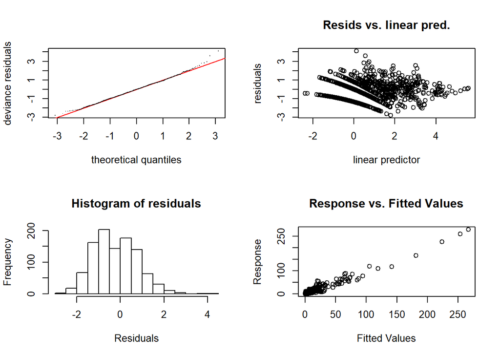

```
##
## Method: REML   Optimizer: outer newton
## full convergence after 17 iterations.
## Gradient range [-4.708103e-05,4.047922e-05]
## (score 2071.374 & scale 1).
## eigenvalue range [-4.047474e-05,63.56027].
## Model rank =  79 / 79
##
## Basis dimension (k) checking results. Low p-value (k-index<1) may
## indicate that k is too low, especially if edf is close to k'.
##
##                                  k'   edf k-index p-value
## s(x,y)                        29.00 13.17    0.65  <2e-16 ***
## s(year)                        2.00  1.78    0.98   0.835
## s(tot_pop)                     9.00  8.05    0.87  <2e-16 ***
## s(mean_house_inc)              9.00  4.23    0.72  <2e-16 ***
## s(opioid_rate_avg)             9.00  5.80    0.97   0.800
## s(alprazolam_per_65_and_over)  9.00  2.00    0.87   0.005 **
## s(lorazepam_per_65_and_over)   9.00  6.31    0.95   0.520
## ---
## Signif. codes:  0 '***' 0.001 '**' 0.01 '*' 0.05 '.' 0.1 ' ' 1
```

```r
gam.check(final_model)
```

```r
concurvity(final_model)
```

```
##              para    s(x,y)   s(year) s(tot_pop) s(mean_house_inc)
## worst    0.469278 0.8209475 0.1190964  0.7254101         0.7013410
## observed 0.469278 0.5007649 0.1071647  0.7051485         0.6761865
## estimate 0.469278 0.2880891 0.1118286  0.2059706         0.4989050
##          s(opioid_rate_avg) s(alprazolam_per_65_and_over)
## worst             0.3749328                     0.8064105
## observed          0.2431755                     0.6276108
## estimate          0.1950281                     0.5231579
##          s(lorazepam_per_65_and_over)
## worst                       0.8070387
## observed                    0.4830209
## estimate                    0.5568402
```

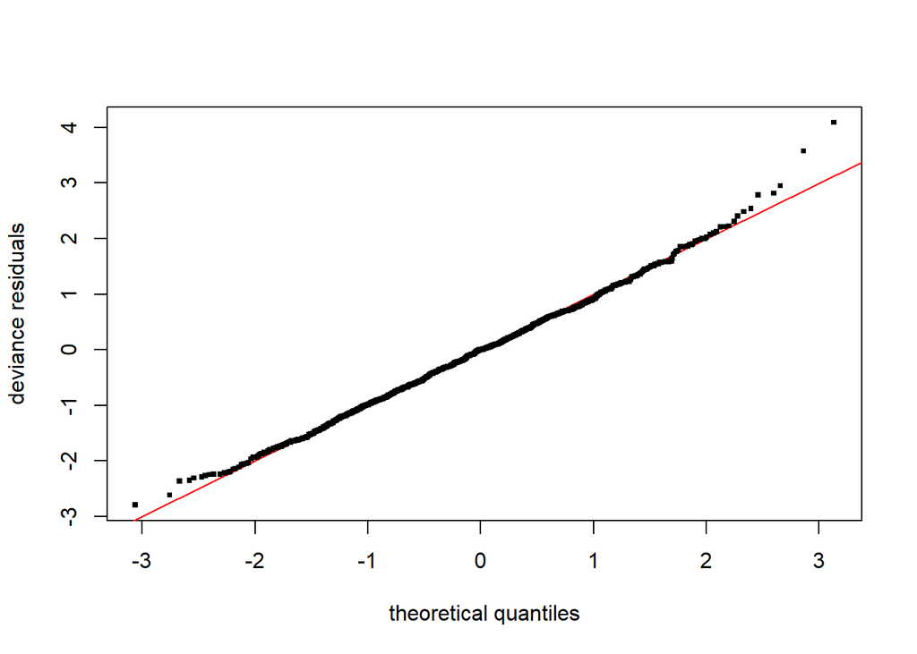

```r
qq.gam(final_model, cex = 4)
```

```r
# error on training
rmse(final_model, train_full)
```

```
## [1] 4.471654
```

```r
# error on validation
rmse(full_model_sub10, test_set)
```

```
## [1] 9.743566
```

```r
rmse(final_model, test_set)
```

```
## [1] 5.305663
```

```r
mean(test_set$death_count_next_year)
```

```
## [1] 7.786561
```

```r
sd(test_set$death_count_next_year)
```

```
## [1] 21.28682
```

Retraining gave a big boost to the predictive power - small difference between training and test set errors suggests that overfitting is not too big of a problem.

Final predictions:

```r
test_set$fin_pred <- predict(final_model, test_set, type = "response")
sd(test_set$fin_pred)
```

```
## [1] 21.67377
```

```r
mod_df_count$fin_pred <- predict(final_model, mod_df_count, type = "response")
```

## Model visualizations

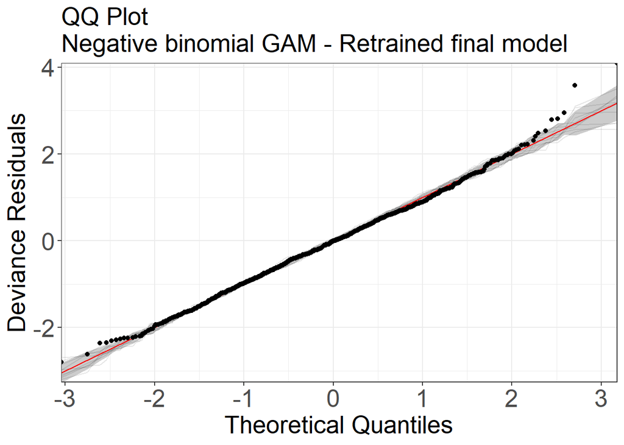

```r
library(mgcViz)
final_model_convert <- getViz(final_model)
final_qq_plot <- qq(final_model_convert, rep = 10, method = "simul1", CI = "normal", showReps = TRUE,
        ngr = 1e2, a.replin = list(alpha = 0.1), a.qqpoi = list(shape = 19)) +
  ggtitle("QQ Plot\nNegative binomial GAM - Retrained final model") +
  xlab("Theoretical Quantiles") +
  ylab("Deviance Residuals") +
  theme(
    axis.text.x = element_text(size = 20),
    axis.text.y = element_text(size = 20),
    axis.title = element_text(size = 20),
    plot.title = element_text(size = 20)
    )
final_qq_plot
```

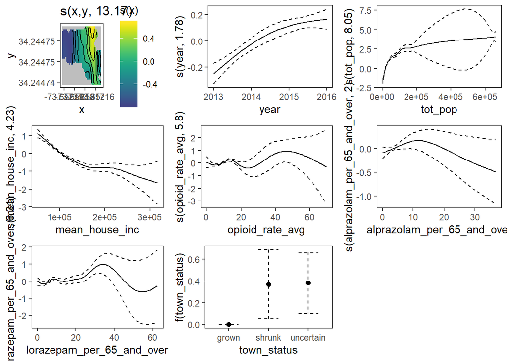

```r
# save_plot doesn't work - save manually in figures/tidy figures/ final_model_retrained_qq_plot.png
# different variations on result plots
print(plot(final_model_convert, allTerms = T), pages = 1)
```

```r
# directly save this from R plot interface to figures/tidy_figures/full_model_gam_plot.png
```

Final model QQ plot shows that most of the variation not captures by the model is at the extremes.

The second plot is a plot of all the feature smooths and their relationship with the smooth. With a GAM, coefficients are not directly interpretable (I think because they need to go through the link function to be converted to the expected outcome, and each feature will have different coefficients through the range of the value for each basis function). But the plot above can help explain the relationship of each individual feature with the target variable.

Testing other model plots, not too useful:

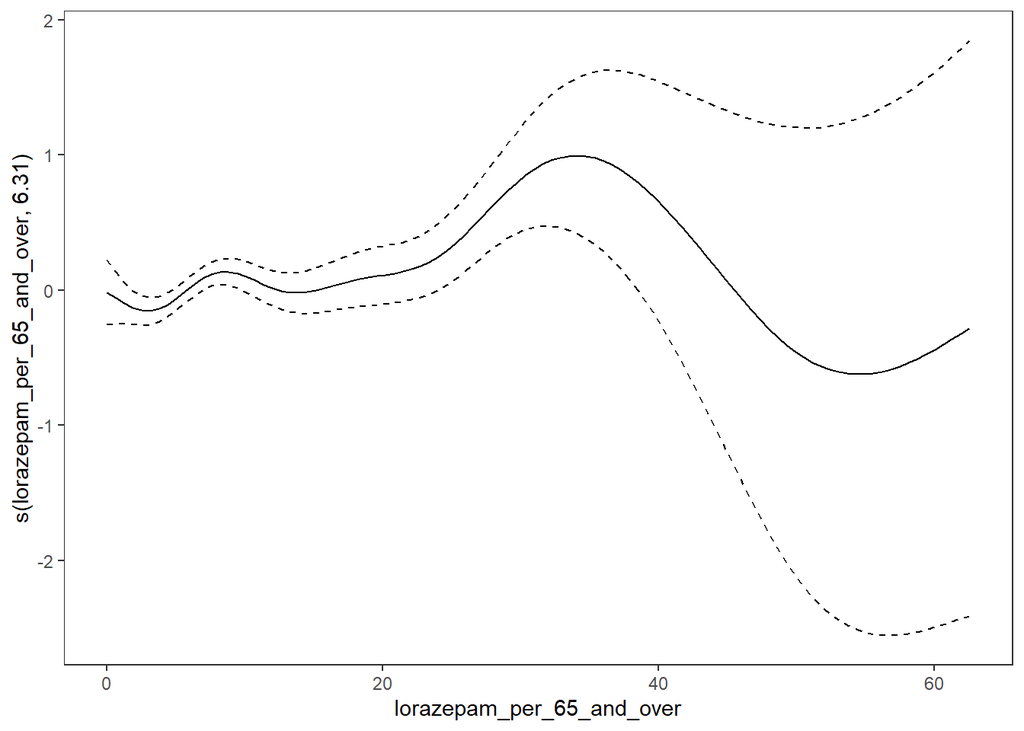

```r
# pick out individual term
plot(final_model_convert, allTerms = T, select = 7)
```

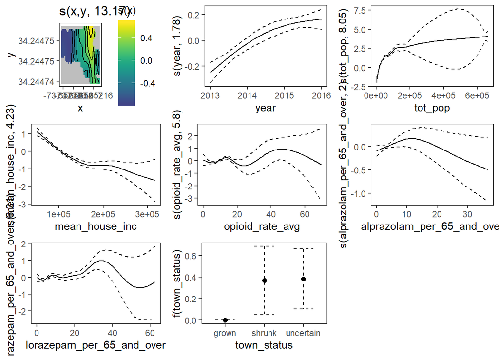

```r
# does changing the residuals setting change anything?
print(plot(final_model_convert, allTerms = T, residuals = TRUE), pages = 1)
```

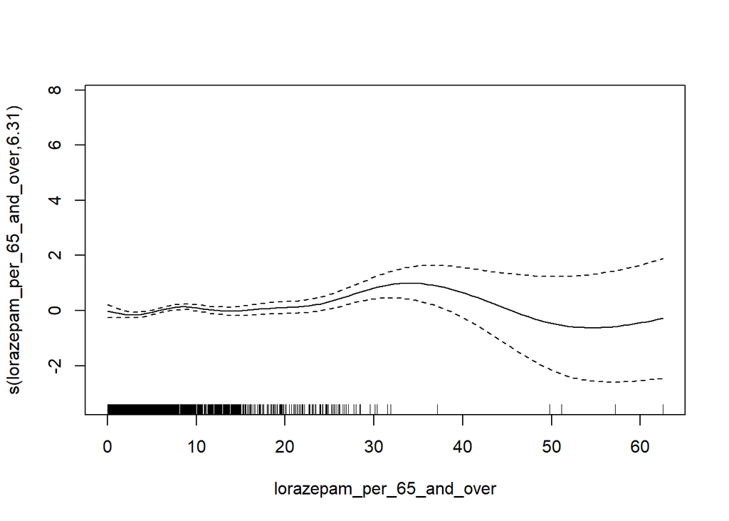

```r
# no
# try with rug (represenin)
plot(final_model, select = 7, rug = TRUE)
```

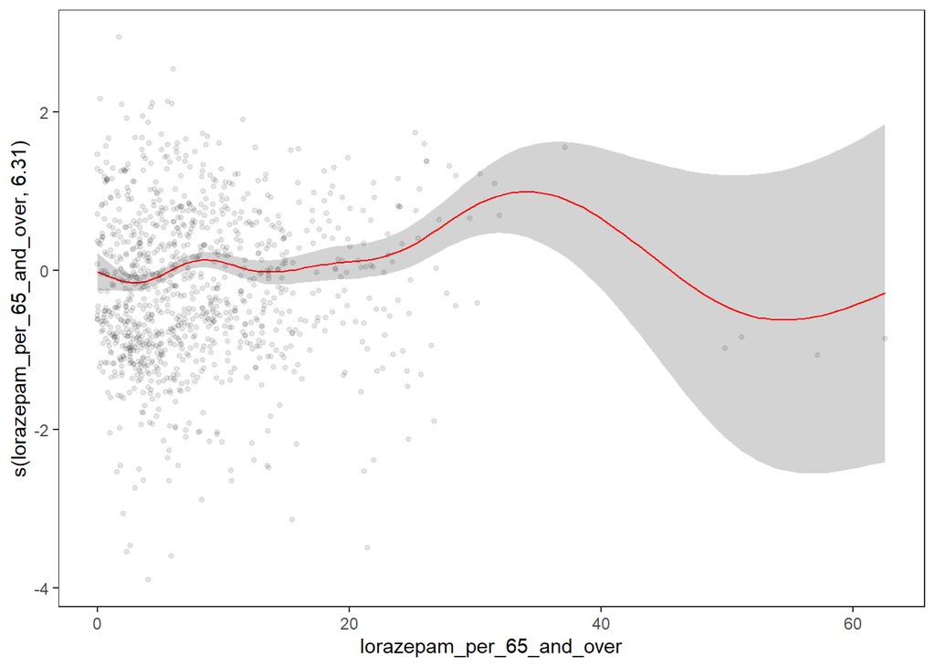

```r
# cleaned up version of one of the individual plots?
var_7 <- plot(sm(final_model_convert, 7))
var_7 +
 # l_rug(mapping = aes(x=x, y=y), alpha = 0.8) +
  l_ciPoly() +
  l_fitLine(colour = "red") +
  #l_ciLine(mul = 5, colour = "blue", linetype = 2) +
  l_points(shape = 19, size = 1, alpha = 0.1)
```

Can see some of the noisiness - need to be wary of interpreting result.

Would tidying up the odel to pull out coefficients be useful?

```r
library(broom)
tidy(final_model)
```

```
## # A tibble: 7 x 5
##   term                            edf ref.df statistic   p.value
##   <chr>                         <dbl>  <dbl>     <dbl>     <dbl>
## 1 s(x,y)                        13.2      29    136.   8.92e- 30
## 2 s(year)                        1.78      2     40.0  1.98e- 10
## 3 s(tot_pop)                     8.05      9    784.   5.33e-186
## 4 s(mean_house_inc)              4.23      9    197.   7.22e- 51
## 5 s(opioid_rate_avg)             5.80      9     34.1  5.95e-  7
## 6 s(alprazolam_per_65_and_over)  2.00      9      6.55 1.52e-  2
## 7 s(lorazepam_per_65_and_over)   6.31      9     29.2  8.40e-  6
```

```r
tidy(final_model, parametric=TRUE)
```

```
## # A tibble: 3 x 5
##   term                 estimate std.error statistic  p.value
##   <chr>                   <dbl>     <dbl>     <dbl>    <dbl>
## 1 (Intercept)             0.695    0.0404     17.2  2.77e-66
## 2 town_statusshrunk       0.371    0.161       2.31 2.10e- 2
## 3 town_statusuncertain    0.383    0.142       2.70 7.01e- 3
```

```r
coef(final_model)
```

[output not shown]

[output cut: 25 more lines]

```
##                    3.415194e-02                    1.592968e-02
## s(alprazolam_per_65_and_over).6 s(alprazolam_per_65_and_over).7
##                   -2.524617e-02                    1.810932e-02
## s(alprazolam_per_65_and_over).8 s(alprazolam_per_65_and_over).9
##                    2.042942e-01                   -1.990891e-06
##  s(lorazepam_per_65_and_over).1  s(lorazepam_per_65_and_over).2
##                    2.332956e-01                    1.177081e+00
##  s(lorazepam_per_65_and_over).3  s(lorazepam_per_65_and_over).4
##                   -3.145849e-01                   -1.289418e+00
##  s(lorazepam_per_65_and_over).5  s(lorazepam_per_65_and_over).6
##                   -3.305723e-01                    1.070874e+00
##  s(lorazepam_per_65_and_over).7  s(lorazepam_per_65_and_over).8
##                    5.024536e-01                   -3.230450e+00
##  s(lorazepam_per_65_and_over).9
##                   -4.498043e-05
```

Not sure what to do with it.

Save the final model df for easier plotting/mapping:

```r
#write_csv(mod_df_count, "../../../data/tidy_data/final_model_df_with_features_and_pred.csv")
```